# Wrangling, Analysis and Visualization of WeRateDogs Tweet Data

- Introduction
- Gathering Data
- Assessing Data
- Cleaning Data
- Storing Data
- Analyzing and Visualizing Data
- Conclusions
- References

## Gathering Data

In the cells below, the three pieces of data for this project would be gathered and loaded in the notebook. Different methods would be used to gather them since they are of different file formats and sources.

```python
# Import and install all necessary libraries for this project
import pandas as pd
import numpy as np
import matplotlib.pyplot as plt
%matplotlib inline
import seaborn as sns
sns.set_style('darkgrid')
```

```python
%%HTML
<style type="text/css">
table.dataframe td, table.dataframe th {
    border: 1px  silver solid !important;
  color: black !important;
}
</style>
```

1. Directly download the WeRateDogs Twitter archive data (twitter_archive_enhanced.csv)

```python
df_archive = pd.read_csv('twitter-archive-enhanced.csv')
```

Use the Requests library to download the tweet image prediction (image_predictions.tsv)

```python
import requests
url = "https://d17h27t6h515a5.cloudfront.net/topher/2017/August/599fd2ad_image-predictions/image-predictions.tsv"
file_name = 'image_predictions.tsv'
r = requests.get(url)
with open(file_name, 'wb') as file:
        file.write(r.content)
df_image = pd.read_csv('image_predictions.tsv', sep = '\t')
```

Use the Tweepy library to query additional data via the Twitter API (tweet_json.txt)

```python
import tweepy
from tweepy import OAuthHandler
import json
from timeit import default_timer as timer

# Query Twitter API for each tweet in the Twitter archive and save JSON in a text file
# These are hidden to comply with Twitter's API terms and conditions
# consumer_key = 'HIDDEN'
# consumer_secret = 'HIDDEN'
# access_token = 'HIDDEN'
# access_secret = 'HIDDEN'

# auth = OAuthHandler(consumer_key, consumer_secret)
# auth.set_access_token(access_token, access_secret)

# api = tweepy.API(auth, wait_on_rate_limit=True)

# NOTE TO REVIEWER: this student had mobile verification issues so the following
# Twitter API code was sent to this student from a Udacity instructor
# Tweet IDs for which to gather additional data via Twitter's API
# tweet_ids = df_archive.tweet_id.values
# len(tweet_ids)

# Query Twitter's API for JSON data for each tweet ID in the Twitter archive
# count = 0
# fails_dict = {}
# start = timer()
# Save each tweet's returned JSON as a new line in a .txt file
# with open('tweet_json.txt', 'w') as outfile:
#    This loop will likely take 20-30 minutes to run because of Twitter's rate limit
#    for tweet_id in tweet_ids:
#       count += 1
#       print(str(count) + ": " + str(tweet_id))
#       try:
#           tweet = api.get_status(tweet_id, tweet_mode='extended')
#           print("Success")
#           json.dump(tweet._json, outfile)
#           outfile.write('\n')
#       except tweepy.TweepError as e:
#           print("Fail")
#           fails_dict[tweet_id] = e
#           pass
# end = timer()
# print(end - start)
# print(fails_dict)
```

```python
# Read the .txt file line by line to a dataframe
df_tweet = []
with open ('tweet-json.txt') as file:
    lines = file.read().splitlines()
    for line in lines:
        data = json.loads(line)
        row = {'tweet_id' : data['id'],
            'retweet_count' : data['retweet_count'],
            'favorite_count' : data['favorite_count']}
        df_tweet.append(row)
df_tweet = pd.DataFrame(df_tweet, columns=['tweet_id',
                                        'retweet_count','favorite_count'])
```

## Assessing Data

In this section, using both visual and programmatic assessment, we would detect the quality and tidiness issues associated with this data.

The key points below would be noted in our assessment of the data.

- I only want original ratings (no retweets) that have images.
- The requirements of this project are only to assess and clean at least 8 quality issues and at least 2 tidiness issues in this dataset.
- The fact that the rating numerators are greater than the denominators does not need to be cleaned. This [unique rating system](http://knowyourmeme.com/memes/theyre-good-dogs-brent) is a big part of the popularity of WeRateDogs.
- I do not need to gather the tweets beyond August 1st, 2017.

```python
df_archive
```

|  | tweet_id | in_reply_to_status_id | in_reply_to_user_id | timestamp | source | text | retweeted_status_id | retweeted_status_user_id | retweeted_status_timestamp | expanded_urls | rating_numerator | rating_denominator | name | doggo | floofer | pupper | puppo |
| --- | --- | --- | --- | --- | --- | --- | --- | --- | --- | --- | --- | --- | --- | --- | --- | --- | --- |
| 0 | 892420643555336193 | NaN | NaN | 2017-08-01 16:23:56 +0000 | <a href="http://twitter.com/download/iphone" r... | This is Phineas. He's a mystical boy. Only eve... | NaN | NaN | NaN | https://twitter.com/dog_rates/status/892420643... | 13 | 10 | Phineas | None | None | None | None |
| 1 | 892177421306343426 | NaN | NaN | 2017-08-01 00:17:27 +0000 | <a href="http://twitter.com/download/iphone" r... | This is Tilly. She's just checking pup on you.... | NaN | NaN | NaN | https://twitter.com/dog_rates/status/892177421... | 13 | 10 | Tilly | None | None | None | None |
| 2 | 891815181378084864 | NaN | NaN | 2017-07-31 00:18:03 +0000 | <a href="http://twitter.com/download/iphone" r... | This is Archie. He is a rare Norwegian Pouncin... | NaN | NaN | NaN | https://twitter.com/dog_rates/status/891815181... | 12 | 10 | Archie | None | None | None | None |
| 3 | 891689557279858688 | NaN | NaN | 2017-07-30 15:58:51 +0000 | <a href="http://twitter.com/download/iphone" r... | This is Darla. She commenced a snooze mid meal... | NaN | NaN | NaN | https://twitter.com/dog_rates/status/891689557... | 13 | 10 | Darla | None | None | None | None |
| 4 | 891327558926688256 | NaN | NaN | 2017-07-29 16:00:24 +0000 | <a href="http://twitter.com/download/iphone" r... | This is Franklin. He would like you to stop ca... | NaN | NaN | NaN | https://twitter.com/dog_rates/status/891327558... | 12 | 10 | Franklin | None | None | None | None |
| 5 | 891087950875897856 | NaN | NaN | 2017-07-29 00:08:17 +0000 | <a href="http://twitter.com/download/iphone" r... | Here we have a majestic great white breaching ... | NaN | NaN | NaN | https://twitter.com/dog_rates/status/891087950... | 13 | 10 | None | None | None | None | None |
| 6 | 890971913173991426 | NaN | NaN | 2017-07-28 16:27:12 +0000 | <a href="http://twitter.com/download/iphone" r... | Meet Jax. He enjoys ice cream so much he gets ... | NaN | NaN | NaN | https://gofundme.com/ydvmve-surgery-for-jax,ht... | 13 | 10 | Jax | None | None | None | None |
| 7 | 890729181411237888 | NaN | NaN | 2017-07-28 00:22:40 +0000 | <a href="http://twitter.com/download/iphone" r... | When you watch your owner call another dog a g... | NaN | NaN | NaN | https://twitter.com/dog_rates/status/890729181... | 13 | 10 | None | None | None | None | None |
| 8 | 890609185150312448 | NaN | NaN | 2017-07-27 16:25:51 +0000 | <a href="http://twitter.com/download/iphone" r... | This is Zoey. She doesn't want to be one of th... | NaN | NaN | NaN | https://twitter.com/dog_rates/status/890609185... | 13 | 10 | Zoey | None | None | None | None |
| 9 | 890240255349198849 | NaN | NaN | 2017-07-26 15:59:51 +0000 | <a href="http://twitter.com/download/iphone" r... | This is Cassie. She is a college pup. Studying... | NaN | NaN | NaN | https://twitter.com/dog_rates/status/890240255... | 14 | 10 | Cassie | doggo | None | None | None |
| 10 | 890006608113172480 | NaN | NaN | 2017-07-26 00:31:25 +0000 | <a href="http://twitter.com/download/iphone" r... | This is Koda. He is a South Australian decksha... | NaN | NaN | NaN | https://twitter.com/dog_rates/status/890006608... | 13 | 10 | Koda | None | None | None | None |
| 11 | 889880896479866881 | NaN | NaN | 2017-07-25 16:11:53 +0000 | <a href="http://twitter.com/download/iphone" r... | This is Bruno. He is a service shark. Only get... | NaN | NaN | NaN | https://twitter.com/dog_rates/status/889880896... | 13 | 10 | Bruno | None | None | None | None |
| 12 | 889665388333682689 | NaN | NaN | 2017-07-25 01:55:32 +0000 | <a href="http://twitter.com/download/iphone" r... | Here's a puppo that seems to be on the fence a... | NaN | NaN | NaN | https://twitter.com/dog_rates/status/889665388... | 13 | 10 | None | None | None | None | puppo |
| 13 | 889638837579907072 | NaN | NaN | 2017-07-25 00:10:02 +0000 | <a href="http://twitter.com/download/iphone" r... | This is Ted. He does his best. Sometimes that'... | NaN | NaN | NaN | https://twitter.com/dog_rates/status/889638837... | 12 | 10 | Ted | None | None | None | None |
| 14 | 889531135344209921 | NaN | NaN | 2017-07-24 17:02:04 +0000 | <a href="http://twitter.com/download/iphone" r... | This is Stuart. He's sporting his favorite fan... | NaN | NaN | NaN | https://twitter.com/dog_rates/status/889531135... | 13 | 10 | Stuart | None | None | None | puppo |
| 15 | 889278841981685760 | NaN | NaN | 2017-07-24 00:19:32 +0000 | <a href="http://twitter.com/download/iphone" r... | This is Oliver. You're witnessing one of his m... | NaN | NaN | NaN | https://twitter.com/dog_rates/status/889278841... | 13 | 10 | Oliver | None | None | None | None |
| 16 | 888917238123831296 | NaN | NaN | 2017-07-23 00:22:39 +0000 | <a href="http://twitter.com/download/iphone" r... | This is Jim. He found a fren. Taught him how t... | NaN | NaN | NaN | https://twitter.com/dog_rates/status/888917238... | 12 | 10 | Jim | None | None | None | None |
| 17 | 888804989199671297 | NaN | NaN | 2017-07-22 16:56:37 +0000 | <a href="http://twitter.com/download/iphone" r... | This is Zeke. He has a new stick. Very proud o... | NaN | NaN | NaN | https://twitter.com/dog_rates/status/888804989... | 13 | 10 | Zeke | None | None | None | None |
| 18 | 888554962724278272 | NaN | NaN | 2017-07-22 00:23:06 +0000 | <a href="http://twitter.com/download/iphone" r... | This is Ralphus. He's powering up. Attempting ... | NaN | NaN | NaN | https://twitter.com/dog_rates/status/888554962... | 13 | 10 | Ralphus | None | None | None | None |
| 19 | 888202515573088257 | NaN | NaN | 2017-07-21 01:02:36 +0000 | <a href="http://twitter.com/download/iphone" r... | RT @dog_rates: This is Canela. She attempted s... | 8.874740e+17 | 4.196984e+09 | 2017-07-19 00:47:34 +0000 | https://twitter.com/dog_rates/status/887473957... | 13 | 10 | Canela | None | None | None | None |
| 20 | 888078434458587136 | NaN | NaN | 2017-07-20 16:49:33 +0000 | <a href="http://twitter.com/download/iphone" r... | This is Gerald. He was just told he didn't get... | NaN | NaN | NaN | https://twitter.com/dog_rates/status/888078434... | 12 | 10 | Gerald | None | None | None | None |
| 21 | 887705289381826560 | NaN | NaN | 2017-07-19 16:06:48 +0000 | <a href="http://twitter.com/download/iphone" r... | This is Jeffrey. He has a monopoly on the pool... | NaN | NaN | NaN | https://twitter.com/dog_rates/status/887705289... | 13 | 10 | Jeffrey | None | None | None | None |
| 22 | 887517139158093824 | NaN | NaN | 2017-07-19 03:39:09 +0000 | <a href="http://twitter.com/download/iphone" r... | I've yet to rate a Venezuelan Hover Wiener. Th... | NaN | NaN | NaN | https://twitter.com/dog_rates/status/887517139... | 14 | 10 | such | None | None | None | None |
| 23 | 887473957103951883 | NaN | NaN | 2017-07-19 00:47:34 +0000 | <a href="http://twitter.com/download/iphone" r... | This is Canela. She attempted some fancy porch... | NaN | NaN | NaN | https://twitter.com/dog_rates/status/887473957... | 13 | 10 | Canela | None | None | None | None |
| 24 | 887343217045368832 | NaN | NaN | 2017-07-18 16:08:03 +0000 | <a href="http://twitter.com/download/iphone" r... | You may not have known you needed to see this ... | NaN | NaN | NaN | https://twitter.com/dog_rates/status/887343217... | 13 | 10 | None | None | None | None | None |
| 25 | 887101392804085760 | NaN | NaN | 2017-07-18 00:07:08 +0000 | <a href="http://twitter.com/download/iphone" r... | This... is a Jubilant Antarctic House Bear. We... | NaN | NaN | NaN | https://twitter.com/dog_rates/status/887101392... | 12 | 10 | None | None | None | None | None |
| 26 | 886983233522544640 | NaN | NaN | 2017-07-17 16:17:36 +0000 | <a href="http://twitter.com/download/iphone" r... | This is Maya. She's very shy. Rarely leaves he... | NaN | NaN | NaN | https://twitter.com/dog_rates/status/886983233... | 13 | 10 | Maya | None | None | None | None |
| 27 | 886736880519319552 | NaN | NaN | 2017-07-16 23:58:41 +0000 | <a href="http://twitter.com/download/iphone" r... | This is Mingus. He's a wonderful father to his... | NaN | NaN | NaN | https://www.gofundme.com/mingusneedsus,https:/... | 13 | 10 | Mingus | None | None | None | None |
| 28 | 886680336477933568 | NaN | NaN | 2017-07-16 20:14:00 +0000 | <a href="http://twitter.com/download/iphone" r... | This is Derek. He's late for a dog meeting. 13... | NaN | NaN | NaN | https://twitter.com/dog_rates/status/886680336... | 13 | 10 | Derek | None | None | None | None |
| 29 | 886366144734445568 | NaN | NaN | 2017-07-15 23:25:31 +0000 | <a href="http://twitter.com/download/iphone" r... | This is Roscoe. Another pupper fallen victim t... | NaN | NaN | NaN | https://twitter.com/dog_rates/status/886366144... | 12 | 10 | Roscoe | None | None | pupper | None |
| ... | ... | ... | ... | ... | ... | ... | ... | ... | ... | ... | ... | ... | ... | ... | ... | ... | ... |
| 2326 | 666411507551481857 | NaN | NaN | 2015-11-17 00:24:19 +0000 | <a href="http://twitter.com/download/iphone" r... | This is quite the dog. Gets really excited whe... | NaN | NaN | NaN | https://twitter.com/dog_rates/status/666411507... | 2 | 10 | quite | None | None | None | None |
| 2327 | 666407126856765440 | NaN | NaN | 2015-11-17 00:06:54 +0000 | <a href="http://twitter.com/download/iphone" r... | This is a southern Vesuvius bumblegruff. Can d... | NaN | NaN | NaN | https://twitter.com/dog_rates/status/666407126... | 7 | 10 | a | None | None | None | None |
| 2328 | 666396247373291520 | NaN | NaN | 2015-11-16 23:23:41 +0000 | <a href="http://twitter.com/download/iphone" r... | Oh goodness. A super rare northeast Qdoba kang... | NaN | NaN | NaN | https://twitter.com/dog_rates/status/666396247... | 9 | 10 | None | None | None | None | None |
| 2329 | 666373753744588802 | NaN | NaN | 2015-11-16 21:54:18 +0000 | <a href="http://twitter.com/download/iphone" r... | Those are sunglasses and a jean jacket. 11/10 ... | NaN | NaN | NaN | https://twitter.com/dog_rates/status/666373753... | 11 | 10 | None | None | None | None | None |
| 2330 | 666362758909284353 | NaN | NaN | 2015-11-16 21:10:36 +0000 | <a href="http://twitter.com/download/iphone" r... | Unique dog here. Very small. Lives in containe... | NaN | NaN | NaN | https://twitter.com/dog_rates/status/666362758... | 6 | 10 | None | None | None | None | None |
| 2331 | 666353288456101888 | NaN | NaN | 2015-11-16 20:32:58 +0000 | <a href="http://twitter.com/download/iphone" r... | Here we have a mixed Asiago from the Galápagos... | NaN | NaN | NaN | https://twitter.com/dog_rates/status/666353288... | 8 | 10 | None | None | None | None | None |
| 2332 | 666345417576210432 | NaN | NaN | 2015-11-16 20:01:42 +0000 | <a href="http://twitter.com/download/iphone" r... | Look at this jokester thinking seat belt laws ... | NaN | NaN | NaN | https://twitter.com/dog_rates/status/666345417... | 10 | 10 | None | None | None | None | None |
| 2333 | 666337882303524864 | NaN | NaN | 2015-11-16 19:31:45 +0000 | <a href="http://twitter.com/download/iphone" r... | This is an extremely rare horned Parthenon. No... | NaN | NaN | NaN | https://twitter.com/dog_rates/status/666337882... | 9 | 10 | an | None | None | None | None |
| 2334 | 666293911632134144 | NaN | NaN | 2015-11-16 16:37:02 +0000 | <a href="http://twitter.com/download/iphone" r... | This is a funny dog. Weird toes. Won't come do... | NaN | NaN | NaN | https://twitter.com/dog_rates/status/666293911... | 3 | 10 | a | None | None | None | None |
| 2335 | 666287406224695296 | NaN | NaN | 2015-11-16 16:11:11 +0000 | <a href="http://twitter.com/download/iphone" r... | This is an Albanian 3 1/2 legged Episcopalian... | NaN | NaN | NaN | https://twitter.com/dog_rates/status/666287406... | 1 | 2 | an | None | None | None | None |
| 2336 | 666273097616637952 | NaN | NaN | 2015-11-16 15:14:19 +0000 | <a href="http://twitter.com/download/iphone" r... | Can take selfies 11/10 https://t.co/ws2AMaNwPW | NaN | NaN | NaN | https://twitter.com/dog_rates/status/666273097... | 11 | 10 | None | None | None | None | None |
| 2337 | 666268910803644416 | NaN | NaN | 2015-11-16 14:57:41 +0000 | <a href="http://twitter.com/download/iphone" r... | Very concerned about fellow dog trapped in com... | NaN | NaN | NaN | https://twitter.com/dog_rates/status/666268910... | 10 | 10 | None | None | None | None | None |
| 2338 | 666104133288665088 | NaN | NaN | 2015-11-16 04:02:55 +0000 | <a href="http://twitter.com/download/iphone" r... | Not familiar with this breed. No tail (weird).... | NaN | NaN | NaN | https://twitter.com/dog_rates/status/666104133... | 1 | 10 | None | None | None | None | None |
| 2339 | 666102155909144576 | NaN | NaN | 2015-11-16 03:55:04 +0000 | <a href="http://twitter.com/download/iphone" r... | Oh my. Here you are seeing an Adobe Setter giv... | NaN | NaN | NaN | https://twitter.com/dog_rates/status/666102155... | 11 | 10 | None | None | None | None | None |
| 2340 | 666099513787052032 | NaN | NaN | 2015-11-16 03:44:34 +0000 | <a href="http://twitter.com/download/iphone" r... | Can stand on stump for what seems like a while... | NaN | NaN | NaN | https://twitter.com/dog_rates/status/666099513... | 8 | 10 | None | None | None | None | None |
| 2341 | 666094000022159362 | NaN | NaN | 2015-11-16 03:22:39 +0000 | <a href="http://twitter.com/download/iphone" r... | This appears to be a Mongolian Presbyterian mi... | NaN | NaN | NaN | https://twitter.com/dog_rates/status/666094000... | 9 | 10 | None | None | None | None | None |
| 2342 | 666082916733198337 | NaN | NaN | 2015-11-16 02:38:37 +0000 | <a href="http://twitter.com/download/iphone" r... | Here we have a well-established sunblockerspan... | NaN | NaN | NaN | https://twitter.com/dog_rates/status/666082916... | 6 | 10 | None | None | None | None | None |
| 2343 | 666073100786774016 | NaN | NaN | 2015-11-16 01:59:36 +0000 | <a href="http://twitter.com/download/iphone" r... | Let's hope this flight isn't Malaysian (lol). ... | NaN | NaN | NaN | https://twitter.com/dog_rates/status/666073100... | 10 | 10 | None | None | None | None | None |
| 2344 | 666071193221509120 | NaN | NaN | 2015-11-16 01:52:02 +0000 | <a href="http://twitter.com/download/iphone" r... | Here we have a northern speckled Rhododendron.... | NaN | NaN | NaN | https://twitter.com/dog_rates/status/666071193... | 9 | 10 | None | None | None | None | None |
| 2345 | 666063827256086533 | NaN | NaN | 2015-11-16 01:22:45 +0000 | <a href="http://twitter.com/download/iphone" r... | This is the happiest dog you will ever see. Ve... | NaN | NaN | NaN | https://twitter.com/dog_rates/status/666063827... | 10 | 10 | the | None | None | None | None |
| 2346 | 666058600524156928 | NaN | NaN | 2015-11-16 01:01:59 +0000 | <a href="http://twitter.com/download/iphone" r... | Here is the Rand Paul of retrievers folks! He'... | NaN | NaN | NaN | https://twitter.com/dog_rates/status/666058600... | 8 | 10 | the | None | None | None | None |
| 2347 | 666057090499244032 | NaN | NaN | 2015-11-16 00:55:59 +0000 | <a href="http://twitter.com/download/iphone" r... | My oh my. This is a rare blond Canadian terrie... | NaN | NaN | NaN | https://twitter.com/dog_rates/status/666057090... | 9 | 10 | a | None | None | None | None |
| 2348 | 666055525042405380 | NaN | NaN | 2015-11-16 00:49:46 +0000 | <a href="http://twitter.com/download/iphone" r... | Here is a Siberian heavily armored polar bear ... | NaN | NaN | NaN | https://twitter.com/dog_rates/status/666055525... | 10 | 10 | a | None | None | None | None |
| 2349 | 666051853826850816 | NaN | NaN | 2015-11-16 00:35:11 +0000 | <a href="http://twitter.com/download/iphone" r... | This is an odd dog. Hard on the outside but lo... | NaN | NaN | NaN | https://twitter.com/dog_rates/status/666051853... | 2 | 10 | an | None | None | None | None |
| 2350 | 666050758794694657 | NaN | NaN | 2015-11-16 00:30:50 +0000 | <a href="http://twitter.com/download/iphone" r... | This is a truly beautiful English Wilson Staff... | NaN | NaN | NaN | https://twitter.com/dog_rates/status/666050758... | 10 | 10 | a | None | None | None | None |
| 2351 | 666049248165822465 | NaN | NaN | 2015-11-16 00:24:50 +0000 | <a href="http://twitter.com/download/iphone" r... | Here we have a 1949 1st generation vulpix. Enj... | NaN | NaN | NaN | https://twitter.com/dog_rates/status/666049248... | 5 | 10 | None | None | None | None | None |
| 2352 | 666044226329800704 | NaN | NaN | 2015-11-16 00:04:52 +0000 | <a href="http://twitter.com/download/iphone" r... | This is a purebred Piers Morgan. Loves to Netf... | NaN | NaN | NaN | https://twitter.com/dog_rates/status/666044226... | 6 | 10 | a | None | None | None | None |
| 2353 | 666033412701032449 | NaN | NaN | 2015-11-15 23:21:54 +0000 | <a href="http://twitter.com/download/iphone" r... | Here is a very happy pup. Big fan of well-main... | NaN | NaN | NaN | https://twitter.com/dog_rates/status/666033412... | 9 | 10 | a | None | None | None | None |
| 2354 | 666029285002620928 | NaN | NaN | 2015-11-15 23:05:30 +0000 | <a href="http://twitter.com/download/iphone" r... | This is a western brown Mitsubishi terrier. Up... | NaN | NaN | NaN | https://twitter.com/dog_rates/status/666029285... | 7 | 10 | a | None | None | None | None |
| 2355 | 666020888022790149 | NaN | NaN | 2015-11-15 22:32:08 +0000 | <a href="http://twitter.com/download/iphone" r... | Here we have a Japanese Irish Setter. Lost eye... | NaN | NaN | NaN | https://twitter.com/dog_rates/status/666020888... | 8 | 10 | None | None | None | None | None |

2356 rows × 17 columns

```python
df_archive.info()
```

```
<class 'pandas.core.frame.DataFrame'>
RangeIndex: 2356 entries, 0 to 2355
Data columns (total 17 columns):
tweet_id                      2356 non-null int64
in_reply_to_status_id         78 non-null float64
in_reply_to_user_id           78 non-null float64
timestamp                     2356 non-null object
source                        2356 non-null object
text                          2356 non-null object
retweeted_status_id           181 non-null float64
retweeted_status_user_id      181 non-null float64
retweeted_status_timestamp    181 non-null object
expanded_urls                 2297 non-null object
rating_numerator              2356 non-null int64
rating_denominator            2356 non-null int64
name                          2356 non-null object
doggo                         2356 non-null object
floofer                       2356 non-null object
pupper                        2356 non-null object
puppo                         2356 non-null object
dtypes: float64(4), int64(3), object(10)
memory usage: 313.0+ KB
```

```python
df_archive.describe()
```

|  | tweet_id | in_reply_to_status_id | in_reply_to_user_id | retweeted_status_id | retweeted_status_user_id | rating_numerator | rating_denominator |
| --- | --- | --- | --- | --- | --- | --- | --- |
| count | 2.356000e+03 | 7.800000e+01 | 7.800000e+01 | 1.810000e+02 | 1.810000e+02 | 2356.000000 | 2356.000000 |
| mean | 7.427716e+17 | 7.455079e+17 | 2.014171e+16 | 7.720400e+17 | 1.241698e+16 | 13.126486 | 10.455433 |
| std | 6.856705e+16 | 7.582492e+16 | 1.252797e+17 | 6.236928e+16 | 9.599254e+16 | 45.876648 | 6.745237 |
| min | 6.660209e+17 | 6.658147e+17 | 1.185634e+07 | 6.661041e+17 | 7.832140e+05 | 0.000000 | 0.000000 |
| 25% | 6.783989e+17 | 6.757419e+17 | 3.086374e+08 | 7.186315e+17 | 4.196984e+09 | 10.000000 | 10.000000 |
| 50% | 7.196279e+17 | 7.038708e+17 | 4.196984e+09 | 7.804657e+17 | 4.196984e+09 | 11.000000 | 10.000000 |
| 75% | 7.993373e+17 | 8.257804e+17 | 4.196984e+09 | 8.203146e+17 | 4.196984e+09 | 12.000000 | 10.000000 |
| max | 8.924206e+17 | 8.862664e+17 | 8.405479e+17 | 8.874740e+17 | 7.874618e+17 | 1776.000000 | 170.000000 |

```python
df_archive.tweet_id.nunique()
```

```
2356
```

```python
df_archive.text.duplicated().sum()
```

```
0
```

```python
df_archive.name.isnull().sum()
```

```
0
```

```python
df_archive.name.value_counts().head(25)
```

```
None       745
a           55
Charlie     12
Lucy        11
Cooper      11
Oliver      11
Tucker      10
Lola        10
Penny       10
Bo           9
Winston      9
the          8
Sadie        8
Toby         7
an           7
Bailey       7
Daisy        7
Buddy        7
Jax          6
Milo         6
Dave         6
Scout        6
Jack         6
Oscar        6
Rusty        6
Name: name, dtype: int64
```

```python
df_archive.rating_numerator.value_counts()
```

```
12      558
11      464
10      461
13      351
9       158
8       102
7        55
14       54
5        37
6        32
3        19
4        17
1         9
2         9
420       2
```

[output cut: 26 more lines]

```python
df_archive.rating_denominator.value_counts()
```

```
10     2333
11        3
50        3
80        2
20        2
2         1
16        1
40        1
70        1
15        1
90        1
110       1
120       1
130       1
150       1
170       1
7         1
0         1
Name: rating_denominator, dtype: int64
```

```python
df_archive.source.value_counts()
```

```
<a href="http://twitter.com/download/iphone" rel="nofollow">Twitter for iPhone</a>     2221
<a href="http://vine.co" rel="nofollow">Vine - Make a Scene</a>                          91
<a href="http://twitter.com" rel="nofollow">Twitter Web Client</a>                       33
<a href="https://about.twitter.com/products/tweetdeck" rel="nofollow">TweetDeck</a>      11
Name: source, dtype: int64
```

```python
df_image
```

|  | tweet_id | jpg_url | img_num | p1 | p1_conf | p1_dog | p2 | p2_conf | p2_dog | p3 | p3_conf | p3_dog |
| --- | --- | --- | --- | --- | --- | --- | --- | --- | --- | --- | --- | --- |
| 0 | 666020888022790149 | https://pbs.twimg.com/media/CT4udn0WwAA0aMy.jpg | 1 | Welsh_springer_spaniel | 0.465074 | True | collie | 0.156665 | True | Shetland_sheepdog | 0.061428 | True |
| 1 | 666029285002620928 | https://pbs.twimg.com/media/CT42GRgUYAA5iDo.jpg | 1 | redbone | 0.506826 | True | miniature_pinscher | 0.074192 | True | Rhodesian_ridgeback | 0.072010 | True |
| 2 | 666033412701032449 | https://pbs.twimg.com/media/CT4521TWwAEvMyu.jpg | 1 | German_shepherd | 0.596461 | True | malinois | 0.138584 | True | bloodhound | 0.116197 | True |
| 3 | 666044226329800704 | https://pbs.twimg.com/media/CT5Dr8HUEAA-lEu.jpg | 1 | Rhodesian_ridgeback | 0.408143 | True | redbone | 0.360687 | True | miniature_pinscher | 0.222752 | True |
| 4 | 666049248165822465 | https://pbs.twimg.com/media/CT5IQmsXIAAKY4A.jpg | 1 | miniature_pinscher | 0.560311 | True | Rottweiler | 0.243682 | True | Doberman | 0.154629 | True |
| 5 | 666050758794694657 | https://pbs.twimg.com/media/CT5Jof1WUAEuVxN.jpg | 1 | Bernese_mountain_dog | 0.651137 | True | English_springer | 0.263788 | True | Greater_Swiss_Mountain_dog | 0.016199 | True |
| 6 | 666051853826850816 | https://pbs.twimg.com/media/CT5KoJ1WoAAJash.jpg | 1 | box_turtle | 0.933012 | False | mud_turtle | 0.045885 | False | terrapin | 0.017885 | False |
| 7 | 666055525042405380 | https://pbs.twimg.com/media/CT5N9tpXIAAifs1.jpg | 1 | chow | 0.692517 | True | Tibetan_mastiff | 0.058279 | True | fur_coat | 0.054449 | False |
| 8 | 666057090499244032 | https://pbs.twimg.com/media/CT5PY90WoAAQGLo.jpg | 1 | shopping_cart | 0.962465 | False | shopping_basket | 0.014594 | False | golden_retriever | 0.007959 | True |
| 9 | 666058600524156928 | https://pbs.twimg.com/media/CT5Qw94XAAA_2dP.jpg | 1 | miniature_poodle | 0.201493 | True | komondor | 0.192305 | True | soft-coated_wheaten_terrier | 0.082086 | True |
| 10 | 666063827256086533 | https://pbs.twimg.com/media/CT5Vg_wXIAAXfnj.jpg | 1 | golden_retriever | 0.775930 | True | Tibetan_mastiff | 0.093718 | True | Labrador_retriever | 0.072427 | True |
| 11 | 666071193221509120 | https://pbs.twimg.com/media/CT5cN_3WEAAlOoZ.jpg | 1 | Gordon_setter | 0.503672 | True | Yorkshire_terrier | 0.174201 | True | Pekinese | 0.109454 | True |
| 12 | 666073100786774016 | https://pbs.twimg.com/media/CT5d9DZXAAALcwe.jpg | 1 | Walker_hound | 0.260857 | True | English_foxhound | 0.175382 | True | Ibizan_hound | 0.097471 | True |
| 13 | 666082916733198337 | https://pbs.twimg.com/media/CT5m4VGWEAAtKc8.jpg | 1 | pug | 0.489814 | True | bull_mastiff | 0.404722 | True | French_bulldog | 0.048960 | True |
| 14 | 666094000022159362 | https://pbs.twimg.com/media/CT5w9gUW4AAsBNN.jpg | 1 | bloodhound | 0.195217 | True | German_shepherd | 0.078260 | True | malinois | 0.075628 | True |
| 15 | 666099513787052032 | https://pbs.twimg.com/media/CT51-JJUEAA6hV8.jpg | 1 | Lhasa | 0.582330 | True | Shih-Tzu | 0.166192 | True | Dandie_Dinmont | 0.089688 | True |
| 16 | 666102155909144576 | https://pbs.twimg.com/media/CT54YGiWUAEZnoK.jpg | 1 | English_setter | 0.298617 | True | Newfoundland | 0.149842 | True | borzoi | 0.133649 | True |
| 17 | 666104133288665088 | https://pbs.twimg.com/media/CT56LSZWoAAlJj2.jpg | 1 | hen | 0.965932 | False | cock | 0.033919 | False | partridge | 0.000052 | False |
| 18 | 666268910803644416 | https://pbs.twimg.com/media/CT8QCd1WEAADXws.jpg | 1 | desktop_computer | 0.086502 | False | desk | 0.085547 | False | bookcase | 0.079480 | False |
| 19 | 666273097616637952 | https://pbs.twimg.com/media/CT8T1mtUwAA3aqm.jpg | 1 | Italian_greyhound | 0.176053 | True | toy_terrier | 0.111884 | True | basenji | 0.111152 | True |
| 20 | 666287406224695296 | https://pbs.twimg.com/media/CT8g3BpUEAAuFjg.jpg | 1 | Maltese_dog | 0.857531 | True | toy_poodle | 0.063064 | True | miniature_poodle | 0.025581 | True |
| 21 | 666293911632134144 | https://pbs.twimg.com/media/CT8mx7KW4AEQu8N.jpg | 1 | three-toed_sloth | 0.914671 | False | otter | 0.015250 | False | great_grey_owl | 0.013207 | False |
| 22 | 666337882303524864 | https://pbs.twimg.com/media/CT9OwFIWEAMuRje.jpg | 1 | ox | 0.416669 | False | Newfoundland | 0.278407 | True | groenendael | 0.102643 | True |
| 23 | 666345417576210432 | https://pbs.twimg.com/media/CT9Vn7PWoAA_ZCM.jpg | 1 | golden_retriever | 0.858744 | True | Chesapeake_Bay_retriever | 0.054787 | True | Labrador_retriever | 0.014241 | True |
| 24 | 666353288456101888 | https://pbs.twimg.com/media/CT9cx0tUEAAhNN_.jpg | 1 | malamute | 0.336874 | True | Siberian_husky | 0.147655 | True | Eskimo_dog | 0.093412 | True |
| 25 | 666362758909284353 | https://pbs.twimg.com/media/CT9lXGsUcAAyUFt.jpg | 1 | guinea_pig | 0.996496 | False | skunk | 0.002402 | False | hamster | 0.000461 | False |
| 26 | 666373753744588802 | https://pbs.twimg.com/media/CT9vZEYWUAAlZ05.jpg | 1 | soft-coated_wheaten_terrier | 0.326467 | True | Afghan_hound | 0.259551 | True | briard | 0.206803 | True |
| 27 | 666396247373291520 | https://pbs.twimg.com/media/CT-D2ZHWIAA3gK1.jpg | 1 | Chihuahua | 0.978108 | True | toy_terrier | 0.009397 | True | papillon | 0.004577 | True |
| 28 | 666407126856765440 | https://pbs.twimg.com/media/CT-NvwmW4AAugGZ.jpg | 1 | black-and-tan_coonhound | 0.529139 | True | bloodhound | 0.244220 | True | flat-coated_retriever | 0.173810 | True |
| 29 | 666411507551481857 | https://pbs.twimg.com/media/CT-RugiWIAELEaq.jpg | 1 | coho | 0.404640 | False | barracouta | 0.271485 | False | gar | 0.189945 | False |
| ... | ... | ... | ... | ... | ... | ... | ... | ... | ... | ... | ... | ... |
| 2045 | 886366144734445568 | https://pbs.twimg.com/media/DE0BTnQUwAApKEH.jpg | 1 | French_bulldog | 0.999201 | True | Chihuahua | 0.000361 | True | Boston_bull | 0.000076 | True |
| 2046 | 886680336477933568 | https://pbs.twimg.com/media/DE4fEDzWAAAyHMM.jpg | 1 | convertible | 0.738995 | False | sports_car | 0.139952 | False | car_wheel | 0.044173 | False |
| 2047 | 886736880519319552 | https://pbs.twimg.com/media/DE5Se8FXcAAJFx4.jpg | 1 | kuvasz | 0.309706 | True | Great_Pyrenees | 0.186136 | True | Dandie_Dinmont | 0.086346 | True |
| 2048 | 886983233522544640 | https://pbs.twimg.com/media/DE8yicJW0AAAvBJ.jpg | 2 | Chihuahua | 0.793469 | True | toy_terrier | 0.143528 | True | can_opener | 0.032253 | False |
| 2049 | 887101392804085760 | https://pbs.twimg.com/media/DE-eAq6UwAA-jaE.jpg | 1 | Samoyed | 0.733942 | True | Eskimo_dog | 0.035029 | True | Staffordshire_bullterrier | 0.029705 | True |
| 2050 | 887343217045368832 | https://pbs.twimg.com/ext_tw_video_thumb/88734... | 1 | Mexican_hairless | 0.330741 | True | sea_lion | 0.275645 | False | Weimaraner | 0.134203 | True |
| 2051 | 887473957103951883 | https://pbs.twimg.com/media/DFDw2tyUQAAAFke.jpg | 2 | Pembroke | 0.809197 | True | Rhodesian_ridgeback | 0.054950 | True | beagle | 0.038915 | True |
| 2052 | 887517139158093824 | https://pbs.twimg.com/ext_tw_video_thumb/88751... | 1 | limousine | 0.130432 | False | tow_truck | 0.029175 | False | shopping_cart | 0.026321 | False |
| 2053 | 887705289381826560 | https://pbs.twimg.com/media/DFHDQBbXgAEqY7t.jpg | 1 | basset | 0.821664 | True | redbone | 0.087582 | True | Weimaraner | 0.026236 | True |
| 2054 | 888078434458587136 | https://pbs.twimg.com/media/DFMWn56WsAAkA7B.jpg | 1 | French_bulldog | 0.995026 | True | pug | 0.000932 | True | bull_mastiff | 0.000903 | True |
| 2055 | 888202515573088257 | https://pbs.twimg.com/media/DFDw2tyUQAAAFke.jpg | 2 | Pembroke | 0.809197 | True | Rhodesian_ridgeback | 0.054950 | True | beagle | 0.038915 | True |
| 2056 | 888554962724278272 | https://pbs.twimg.com/media/DFTH_O-UQAACu20.jpg | 3 | Siberian_husky | 0.700377 | True | Eskimo_dog | 0.166511 | True | malamute | 0.111411 | True |
| 2057 | 888804989199671297 | https://pbs.twimg.com/media/DFWra-3VYAA2piG.jpg | 1 | golden_retriever | 0.469760 | True | Labrador_retriever | 0.184172 | True | English_setter | 0.073482 | True |
| 2058 | 888917238123831296 | https://pbs.twimg.com/media/DFYRgsOUQAARGhO.jpg | 1 | golden_retriever | 0.714719 | True | Tibetan_mastiff | 0.120184 | True | Labrador_retriever | 0.105506 | True |
| 2059 | 889278841981685760 | https://pbs.twimg.com/ext_tw_video_thumb/88927... | 1 | whippet | 0.626152 | True | borzoi | 0.194742 | True | Saluki | 0.027351 | True |
| 2060 | 889531135344209921 | https://pbs.twimg.com/media/DFg_2PVW0AEHN3p.jpg | 1 | golden_retriever | 0.953442 | True | Labrador_retriever | 0.013834 | True | redbone | 0.007958 | True |
| 2061 | 889638837579907072 | https://pbs.twimg.com/media/DFihzFfXsAYGDPR.jpg | 1 | French_bulldog | 0.991650 | True | boxer | 0.002129 | True | Staffordshire_bullterrier | 0.001498 | True |
| 2062 | 889665388333682689 | https://pbs.twimg.com/media/DFi579UWsAAatzw.jpg | 1 | Pembroke | 0.966327 | True | Cardigan | 0.027356 | True | basenji | 0.004633 | True |
| 2063 | 889880896479866881 | https://pbs.twimg.com/media/DFl99B1WsAITKsg.jpg | 1 | French_bulldog | 0.377417 | True | Labrador_retriever | 0.151317 | True | muzzle | 0.082981 | False |
| 2064 | 890006608113172480 | https://pbs.twimg.com/media/DFnwSY4WAAAMliS.jpg | 1 | Samoyed | 0.957979 | True | Pomeranian | 0.013884 | True | chow | 0.008167 | True |
| 2065 | 890240255349198849 | https://pbs.twimg.com/media/DFrEyVuW0AAO3t9.jpg | 1 | Pembroke | 0.511319 | True | Cardigan | 0.451038 | True | Chihuahua | 0.029248 | True |
| 2066 | 890609185150312448 | https://pbs.twimg.com/media/DFwUU__XcAEpyXI.jpg | 1 | Irish_terrier | 0.487574 | True | Irish_setter | 0.193054 | True | Chesapeake_Bay_retriever | 0.118184 | True |
| 2067 | 890729181411237888 | https://pbs.twimg.com/media/DFyBahAVwAAhUTd.jpg | 2 | Pomeranian | 0.566142 | True | Eskimo_dog | 0.178406 | True | Pembroke | 0.076507 | True |
| 2068 | 890971913173991426 | https://pbs.twimg.com/media/DF1eOmZXUAALUcq.jpg | 1 | Appenzeller | 0.341703 | True | Border_collie | 0.199287 | True | ice_lolly | 0.193548 | False |
| 2069 | 891087950875897856 | https://pbs.twimg.com/media/DF3HwyEWsAABqE6.jpg | 1 | Chesapeake_Bay_retriever | 0.425595 | True | Irish_terrier | 0.116317 | True | Indian_elephant | 0.076902 | False |
| 2070 | 891327558926688256 | https://pbs.twimg.com/media/DF6hr6BUMAAzZgT.jpg | 2 | basset | 0.555712 | True | English_springer | 0.225770 | True | German_short-haired_pointer | 0.175219 | True |
| 2071 | 891689557279858688 | https://pbs.twimg.com/media/DF_q7IAWsAEuuN8.jpg | 1 | paper_towel | 0.170278 | False | Labrador_retriever | 0.168086 | True | spatula | 0.040836 | False |
| 2072 | 891815181378084864 | https://pbs.twimg.com/media/DGBdLU1WsAANxJ9.jpg | 1 | Chihuahua | 0.716012 | True | malamute | 0.078253 | True | kelpie | 0.031379 | True |
| 2073 | 892177421306343426 | https://pbs.twimg.com/media/DGGmoV4XsAAUL6n.jpg | 1 | Chihuahua | 0.323581 | True | Pekinese | 0.090647 | True | papillon | 0.068957 | True |
| 2074 | 892420643555336193 | https://pbs.twimg.com/media/DGKD1-bXoAAIAUK.jpg | 1 | orange | 0.097049 | False | bagel | 0.085851 | False | banana | 0.076110 | False |

2075 rows × 12 columns

```python
df_image.info()
```

```
<class 'pandas.core.frame.DataFrame'>
RangeIndex: 2075 entries, 0 to 2074
Data columns (total 12 columns):
tweet_id    2075 non-null int64
jpg_url     2075 non-null object
img_num     2075 non-null int64
p1          2075 non-null object
p1_conf     2075 non-null float64
p1_dog      2075 non-null bool
p2          2075 non-null object
p2_conf     2075 non-null float64
p2_dog      2075 non-null bool
p3          2075 non-null object
p3_conf     2075 non-null float64
p3_dog      2075 non-null bool
dtypes: bool(3), float64(3), int64(2), object(4)
memory usage: 152.1+ KB
```

```python
df_image.describe()
```

|  | tweet_id | img_num | p1_conf | p2_conf | p3_conf |
| --- | --- | --- | --- | --- | --- |
| count | 2.075000e+03 | 2075.000000 | 2075.000000 | 2.075000e+03 | 2.075000e+03 |
| mean | 7.384514e+17 | 1.203855 | 0.594548 | 1.345886e-01 | 6.032417e-02 |
| std | 6.785203e+16 | 0.561875 | 0.271174 | 1.006657e-01 | 5.090593e-02 |
| min | 6.660209e+17 | 1.000000 | 0.044333 | 1.011300e-08 | 1.740170e-10 |
| 25% | 6.764835e+17 | 1.000000 | 0.364412 | 5.388625e-02 | 1.622240e-02 |
| 50% | 7.119988e+17 | 1.000000 | 0.588230 | 1.181810e-01 | 4.944380e-02 |
| 75% | 7.932034e+17 | 1.000000 | 0.843855 | 1.955655e-01 | 9.180755e-02 |
| max | 8.924206e+17 | 4.000000 | 1.000000 | 4.880140e-01 | 2.734190e-01 |

```python
df_image.tweet_id.nunique()
```

```
2075
```

```python
df_image.tweet_id.duplicated().sum()
```

```
0
```

```python
# Query all rows with false dog prediction across p1_dog, p2_dog and p3_dog
df_image.query('p1_dog == False and p2_dog == False and p3_dog == False')
```

|  | tweet_id | jpg_url | img_num | p1 | p1_conf | p1_dog | p2 | p2_conf | p2_dog | p3 | p3_conf | p3_dog |
| --- | --- | --- | --- | --- | --- | --- | --- | --- | --- | --- | --- | --- |
| 6 | 666051853826850816 | https://pbs.twimg.com/media/CT5KoJ1WoAAJash.jpg | 1 | box_turtle | 0.933012 | False | mud_turtle | 4.588540e-02 | False | terrapin | 1.788530e-02 | False |
| 17 | 666104133288665088 | https://pbs.twimg.com/media/CT56LSZWoAAlJj2.jpg | 1 | hen | 0.965932 | False | cock | 3.391940e-02 | False | partridge | 5.206580e-05 | False |
| 18 | 666268910803644416 | https://pbs.twimg.com/media/CT8QCd1WEAADXws.jpg | 1 | desktop_computer | 0.086502 | False | desk | 8.554740e-02 | False | bookcase | 7.947970e-02 | False |
| 21 | 666293911632134144 | https://pbs.twimg.com/media/CT8mx7KW4AEQu8N.jpg | 1 | three-toed_sloth | 0.914671 | False | otter | 1.525000e-02 | False | great_grey_owl | 1.320720e-02 | False |
| 25 | 666362758909284353 | https://pbs.twimg.com/media/CT9lXGsUcAAyUFt.jpg | 1 | guinea_pig | 0.996496 | False | skunk | 2.402450e-03 | False | hamster | 4.608630e-04 | False |
| 29 | 666411507551481857 | https://pbs.twimg.com/media/CT-RugiWIAELEaq.jpg | 1 | coho | 0.404640 | False | barracouta | 2.714850e-01 | False | gar | 1.899450e-01 | False |
| 45 | 666786068205871104 | https://pbs.twimg.com/media/CUDmZIkWcAAIPPe.jpg | 1 | snail | 0.999888 | False | slug | 5.514170e-05 | False | acorn | 2.625800e-05 | False |
| 50 | 666837028449972224 | https://pbs.twimg.com/media/CUEUva1WsAA2jPb.jpg | 1 | triceratops | 0.442113 | False | armadillo | 1.140710e-01 | False | common_iguana | 4.325530e-02 | False |
| 51 | 666983947667116034 | https://pbs.twimg.com/media/CUGaXDhW4AY9JUH.jpg | 1 | swab | 0.589446 | False | chain_saw | 1.901420e-01 | False | wig | 3.450970e-02 | False |
| 53 | 667012601033924608 | https://pbs.twimg.com/media/CUG0bC0U8AAw2su.jpg | 1 | hyena | 0.987230 | False | African_hunting_dog | 1.260080e-02 | False | coyote | 5.735010e-05 | False |
| 56 | 667065535570550784 | https://pbs.twimg.com/media/CUHkkJpXIAA2w3n.jpg | 1 | jigsaw_puzzle | 0.560001 | False | doormat | 1.032590e-01 | False | space_heater | 4.256800e-02 | False |
| 69 | 667188689915760640 | https://pbs.twimg.com/media/CUJUk2iWUAAVtOv.jpg | 1 | vacuum | 0.335830 | False | swab | 2.652780e-01 | False | toilet_tissue | 1.407030e-01 | False |
| 73 | 667369227918143488 | https://pbs.twimg.com/media/CUL4xR9UkAEdlJ6.jpg | 1 | teddy | 0.709545 | False | bath_towel | 1.272850e-01 | False | Christmas_stocking | 2.856750e-02 | False |
| 77 | 667437278097252352 | https://pbs.twimg.com/media/CUM2qWaWoAUZ06L.jpg | 1 | porcupine | 0.989154 | False | bath_towel | 6.300490e-03 | False | badger | 9.663400e-04 | False |
| 78 | 667443425659232256 | https://pbs.twimg.com/media/CUM8QZwW4AAVsBl.jpg | 1 | goose | 0.980815 | False | drake | 6.917770e-03 | False | hen | 5.255170e-03 | False |
| 93 | 667549055577362432 | https://pbs.twimg.com/media/CUOcVCwWsAERUKY.jpg | 1 | electric_fan | 0.984377 | False | spotlight | 7.736710e-03 | False | lampshade | 1.901230e-03 | False |
| 94 | 667550882905632768 | https://pbs.twimg.com/media/CUObvUJVEAAnYPF.jpg | 1 | web_site | 0.998258 | False | dishwasher | 2.010840e-04 | False | oscilloscope | 1.417360e-04 | False |
| 96 | 667724302356258817 | https://pbs.twimg.com/media/CUQ7tv3W4AA3KlI.jpg | 1 | ibex | 0.619098 | False | bighorn | 1.251190e-01 | False | ram | 7.467320e-02 | False |
| 98 | 667766675769573376 | https://pbs.twimg.com/media/CURiQMnUAAAPT2M.jpg | 1 | fire_engine | 0.883493 | False | tow_truck | 7.473390e-02 | False | jeep | 1.277260e-02 | False |
| 100 | 667782464991965184 | https://pbs.twimg.com/media/CURwm3cUkAARcO6.jpg | 1 | lorikeet | 0.466149 | False | hummingbird | 8.301100e-02 | False | African_grey | 5.424740e-02 | False |
| 106 | 667866724293877760 | https://pbs.twimg.com/media/CUS9PlUWwAANeAD.jpg | 1 | jigsaw_puzzle | 1.000000 | False | prayer_rug | 1.011300e-08 | False | doormat | 1.740170e-10 | False |
| 107 | 667873844930215936 | https://pbs.twimg.com/media/CUTDtyGXIAARxus.jpg | 1 | common_iguana | 0.999647 | False | frilled_lizard | 1.811500e-04 | False | African_chameleon | 1.283570e-04 | False |
| 112 | 667911425562669056 | https://pbs.twimg.com/media/CUTl5m1WUAAabZG.jpg | 1 | frilled_lizard | 0.257695 | False | ox | 2.351600e-01 | False | triceratops | 8.531690e-02 | False |
| 115 | 667937095915278337 | https://pbs.twimg.com/media/CUT9PuQWwAABQv7.jpg | 1 | hamster | 0.172078 | False | guinea_pig | 9.492420e-02 | False | Band_Aid | 5.999520e-02 | False |
| 117 | 668142349051129856 | https://pbs.twimg.com/media/CUW37BzWsAAlJlN.jpg | 1 | Angora | 0.918834 | False | hen | 3.779340e-02 | False | wood_rabbit | 1.101490e-02 | False |
| 118 | 668154635664932864 | https://pbs.twimg.com/media/CUXDGR2WcAAUQKz.jpg | 1 | Arctic_fox | 0.473584 | False | wallaby | 2.614110e-01 | False | white_wolf | 8.094780e-02 | False |
| 123 | 668226093875376128 | https://pbs.twimg.com/media/CUYEFlQXAAUkPGm.jpg | 1 | trombone | 0.390339 | False | cornet | 3.141490e-01 | False | French_horn | 2.551820e-01 | False |
| 130 | 668291999406125056 | https://pbs.twimg.com/media/CUZABzGW4AE5F0k.jpg | 1 | web_site | 0.995535 | False | skunk | 1.363490e-03 | False | badger | 6.856500e-04 | False |
| 132 | 668466899341221888 | https://pbs.twimg.com/media/CUbfGbbWoAApZth.jpg | 1 | shopping_basket | 0.398361 | False | hamper | 3.632220e-01 | False | bassinet | 8.417350e-02 | False |
| 140 | 668544745690562560 | https://pbs.twimg.com/media/CUcl5jeWsAA6ufS.jpg | 1 | bearskin | 0.427870 | False | bow | 2.588580e-01 | False | panpipe | 2.156260e-02 | False |
| ... | ... | ... | ... | ... | ... | ... | ... | ... | ... | ... | ... | ... |
| 1839 | 837482249356513284 | https://pbs.twimg.com/media/C59VqMUXEAAzldG.jpg | 2 | birdhouse | 0.541196 | False | can_opener | 1.210940e-01 | False | carton | 5.613670e-02 | False |
| 1844 | 838916489579200512 | https://pbs.twimg.com/media/C6RkiQZUsAAM4R4.jpg | 2 | web_site | 0.993651 | False | monitor | 1.405900e-03 | False | envelope | 1.093090e-03 | False |
| 1847 | 839290600511926273 | https://pbs.twimg.com/media/C6XBt9XXEAEEW9U.jpg | 1 | web_site | 0.670892 | False | monitor | 1.015650e-01 | False | screen | 7.530610e-02 | False |
| 1851 | 840370681858686976 | https://pbs.twimg.com/media/C6mYrK0UwAANhep.jpg | 1 | teapot | 0.981819 | False | cup | 1.402580e-02 | False | coffeepot | 2.420540e-03 | False |
| 1853 | 840696689258311684 | https://pbs.twimg.com/media/C6rBLenU0AAr8MN.jpg | 1 | web_site | 0.841768 | False | rule | 7.087310e-03 | False | envelope | 6.820300e-03 | False |
| 1869 | 844580511645339650 | https://pbs.twimg.com/media/C7iNfq1W0AAcbsR.jpg | 1 | washer | 0.903064 | False | dishwasher | 3.248900e-02 | False | printer | 1.645620e-02 | False |
| 1886 | 847962785489326080 | https://pbs.twimg.com/media/C8SRpHNUIAARB3j.jpg | 1 | sea_lion | 0.882654 | False | mink | 6.688020e-02 | False | otter | 2.567870e-02 | False |
| 1887 | 847971574464610304 | https://pbs.twimg.com/media/C8SZH1EWAAAIRRF.jpg | 1 | coffee_mug | 0.633652 | False | cup | 2.733920e-01 | False | toilet_tissue | 6.665580e-02 | False |
| 1891 | 849051919805034497 | https://pbs.twimg.com/media/C8hwNxbXYAAwyVG.jpg | 1 | fountain | 0.997509 | False | American_black_bear | 1.413120e-03 | False | sundial | 6.811150e-04 | False |
| 1892 | 849336543269576704 | https://pbs.twimg.com/media/C8lzFC4XcAAQxB4.jpg | 1 | patio | 0.521788 | False | prison | 1.495440e-01 | False | restaurant | 2.715260e-02 | False |
| 1900 | 851464819735769094 | https://pbs.twimg.com/media/C9ECujZXsAAPCSM.jpg | 2 | web_site | 0.919649 | False | menu | 2.630610e-02 | False | crossword_puzzle | 3.481510e-03 | False |
| 1902 | 851861385021730816 | https://pbs.twimg.com/media/C8W6sY_W0AEmttW.jpg | 1 | pencil_box | 0.662183 | False | purse | 6.650550e-02 | False | pillow | 4.472530e-02 | False |
| 1905 | 852226086759018497 | https://pbs.twimg.com/ext_tw_video_thumb/85222... | 1 | prison | 0.352793 | False | dishwasher | 1.107230e-01 | False | file | 9.411200e-02 | False |
| 1906 | 852311364735569921 | https://pbs.twimg.com/media/C9QEqZ7XYAIR7fS.jpg | 1 | barbell | 0.971581 | False | dumbbell | 2.841790e-02 | False | go-kart | 5.595040e-07 | False |
| 1910 | 853299958564483072 | https://pbs.twimg.com/media/C9eHyF7XgAAOxPM.jpg | 1 | grille | 0.652280 | False | beach_wagon | 1.128460e-01 | False | convertible | 8.625230e-02 | False |
| 1931 | 859074603037188101 | https://pbs.twimg.com/media/C-wLyufW0AA546I.jpg | 1 | revolver | 0.190292 | False | projectile | 1.490640e-01 | False | fountain | 6.604660e-02 | False |
| 1936 | 860184849394610176 | https://pbs.twimg.com/media/C-_9jWWUwAAnwkd.jpg | 1 | chimpanzee | 0.267612 | False | gorilla | 1.042930e-01 | False | orangutan | 5.990750e-02 | False |
| 1937 | 860276583193509888 | https://pbs.twimg.com/media/C_BQ_NlVwAAgYGD.jpg | 1 | lakeside | 0.312299 | False | dock | 1.598420e-01 | False | canoe | 7.079450e-02 | False |
| 1940 | 860924035999428608 | https://pbs.twimg.com/media/C_KVJjDXsAEUCWn.jpg | 2 | envelope | 0.933016 | False | oscilloscope | 1.259140e-02 | False | paper_towel | 1.117850e-02 | False |
| 1946 | 862457590147678208 | https://pbs.twimg.com/media/C_gQmaTUMAAPYSS.jpg | 1 | home_theater | 0.496348 | False | studio_couch | 1.672560e-01 | False | barber_chair | 5.262500e-02 | False |
| 1953 | 863907417377173506 | https://pbs.twimg.com/media/C_03NPeUQAAgrMl.jpg | 1 | marmot | 0.358828 | False | meerkat | 1.747030e-01 | False | weasel | 1.234850e-01 | False |
| 1956 | 864873206498414592 | https://pbs.twimg.com/media/DAClmHkXcAA1kSv.jpg | 2 | pole | 0.478616 | False | lakeside | 1.141820e-01 | False | wreck | 5.592650e-02 | False |
| 1975 | 870063196459192321 | https://pbs.twimg.com/media/DBMV3NnXUAAm0Pp.jpg | 1 | comic_book | 0.534409 | False | envelope | 2.807220e-01 | False | book_jacket | 4.378550e-02 | False |
| 1979 | 870804317367881728 | https://pbs.twimg.com/media/DBW35ZsVoAEWZUU.jpg | 1 | home_theater | 0.168290 | False | sandbar | 9.804040e-02 | False | television | 7.972940e-02 | False |
| 2012 | 879050749262655488 | https://pbs.twimg.com/media/DDMD_phXoAQ1qf0.jpg | 1 | tabby | 0.311861 | False | window_screen | 1.691230e-01 | False | Egyptian_cat | 1.329320e-01 | False |
| 2021 | 880935762899988482 | https://pbs.twimg.com/media/DDm2Z5aXUAEDS2u.jpg | 1 | street_sign | 0.251801 | False | umbrella | 1.151230e-01 | False | traffic_light | 6.953380e-02 | False |
| 2022 | 881268444196462592 | https://pbs.twimg.com/media/DDrk-f9WAAI-WQv.jpg | 1 | tusker | 0.473303 | False | Indian_elephant | 2.456460e-01 | False | ibex | 5.566070e-02 | False |
| 2046 | 886680336477933568 | https://pbs.twimg.com/media/DE4fEDzWAAAyHMM.jpg | 1 | convertible | 0.738995 | False | sports_car | 1.399520e-01 | False | car_wheel | 4.417270e-02 | False |
| 2052 | 887517139158093824 | https://pbs.twimg.com/ext_tw_video_thumb/88751... | 1 | limousine | 0.130432 | False | tow_truck | 2.917540e-02 | False | shopping_cart | 2.632080e-02 | False |
| 2074 | 892420643555336193 | https://pbs.twimg.com/media/DGKD1-bXoAAIAUK.jpg | 1 | orange | 0.097049 | False | bagel | 8.585110e-02 | False | banana | 7.611000e-02 | False |

324 rows × 12 columns

```python
df_tweet
```

|  | tweet_id | retweet_count | favorite_count |
| --- | --- | --- | --- |
| 0 | 892420643555336193 | 8853 | 39467 |
| 1 | 892177421306343426 | 6514 | 33819 |
| 2 | 891815181378084864 | 4328 | 25461 |
| 3 | 891689557279858688 | 8964 | 42908 |
| 4 | 891327558926688256 | 9774 | 41048 |
| 5 | 891087950875897856 | 3261 | 20562 |
| 6 | 890971913173991426 | 2158 | 12041 |
| 7 | 890729181411237888 | 16716 | 56848 |
| 8 | 890609185150312448 | 4429 | 28226 |
| 9 | 890240255349198849 | 7711 | 32467 |
| 10 | 890006608113172480 | 7624 | 31166 |
| 11 | 889880896479866881 | 5156 | 28268 |
| 12 | 889665388333682689 | 8538 | 38818 |
| 13 | 889638837579907072 | 4735 | 27672 |
| 14 | 889531135344209921 | 2321 | 15359 |
| 15 | 889278841981685760 | 5637 | 25652 |
| 16 | 888917238123831296 | 4709 | 29611 |
| 17 | 888804989199671297 | 4559 | 26080 |
| 18 | 888554962724278272 | 3732 | 20290 |
| 19 | 888078434458587136 | 3653 | 22201 |
| 20 | 887705289381826560 | 5609 | 30779 |
| 21 | 887517139158093824 | 12082 | 46959 |
| 22 | 887473957103951883 | 18781 | 69871 |
| 23 | 887343217045368832 | 10737 | 34222 |
| 24 | 887101392804085760 | 6167 | 31061 |
| 25 | 886983233522544640 | 8084 | 35859 |
| 26 | 886736880519319552 | 3443 | 12306 |
| 27 | 886680336477933568 | 4610 | 22798 |
| 28 | 886366144734445568 | 3316 | 21524 |
| 29 | 886267009285017600 | 4 | 117 |
| ... | ... | ... | ... |
| 2324 | 666411507551481857 | 339 | 459 |
| 2325 | 666407126856765440 | 44 | 113 |
| 2326 | 666396247373291520 | 92 | 172 |
| 2327 | 666373753744588802 | 100 | 194 |
| 2328 | 666362758909284353 | 595 | 804 |
| 2329 | 666353288456101888 | 77 | 229 |
| 2330 | 666345417576210432 | 146 | 307 |
| 2331 | 666337882303524864 | 96 | 204 |
| 2332 | 666293911632134144 | 368 | 522 |
| 2333 | 666287406224695296 | 71 | 152 |
| 2334 | 666273097616637952 | 82 | 184 |
| 2335 | 666268910803644416 | 37 | 108 |
| 2336 | 666104133288665088 | 6871 | 14765 |
| 2337 | 666102155909144576 | 16 | 81 |
| 2338 | 666099513787052032 | 73 | 164 |
| 2339 | 666094000022159362 | 79 | 169 |
| 2340 | 666082916733198337 | 47 | 121 |
| 2341 | 666073100786774016 | 174 | 335 |
| 2342 | 666071193221509120 | 67 | 154 |
| 2343 | 666063827256086533 | 232 | 496 |
| 2344 | 666058600524156928 | 61 | 115 |
| 2345 | 666057090499244032 | 146 | 304 |
| 2346 | 666055525042405380 | 261 | 448 |
| 2347 | 666051853826850816 | 879 | 1253 |
| 2348 | 666050758794694657 | 60 | 136 |
| 2349 | 666049248165822465 | 41 | 111 |
| 2350 | 666044226329800704 | 147 | 311 |
| 2351 | 666033412701032449 | 47 | 128 |
| 2352 | 666029285002620928 | 48 | 132 |
| 2353 | 666020888022790149 | 532 | 2535 |

2354 rows × 3 columns

```python
df_tweet.info()
```

```
<class 'pandas.core.frame.DataFrame'>
RangeIndex: 2354 entries, 0 to 2353
Data columns (total 3 columns):
tweet_id          2354 non-null int64
retweet_count     2354 non-null int64
favorite_count    2354 non-null int64
dtypes: int64(3)
memory usage: 55.2 KB
```

```python
df_tweet.describe()
```

|  | tweet_id | retweet_count | favorite_count |
| --- | --- | --- | --- |
| count | 2.354000e+03 | 2354.000000 | 2354.000000 |
| mean | 7.426978e+17 | 3164.797366 | 8080.968564 |
| std | 6.852812e+16 | 5284.770364 | 11814.771334 |
| min | 6.660209e+17 | 0.000000 | 0.000000 |
| 25% | 6.783975e+17 | 624.500000 | 1415.000000 |
| 50% | 7.194596e+17 | 1473.500000 | 3603.500000 |
| 75% | 7.993058e+17 | 3652.000000 | 10122.250000 |
| max | 8.924206e+17 | 79515.000000 | 132810.000000 |

```python
df_tweet.tweet_id.nunique()
```

```
2354
```

```python
df_tweet.tweet_id.duplicated().sum()
```

```
0
```

### Quality issues

These are issues that are imbedded in the content of the data. A high quality data should be complete, accurate, valid and consistent. From the assessment above, we observed the quality issues below:

1. Irrelevant data related to retweets and status replies in df_archive
2. Erroneous datatypes in the dataframes
3. Invalid dog names
4. Inaccurate dog ratings
5. Hyperlink not extracted from source
6. Irrelevant url at the end of the text in df_archive
7. Inconsistency in letter case of dog breed in df_image
8. Irrelevant columns
9. Non dog image predictions

### Tidiness issues

Untidy data commonly referred to as messy data have structural issues. For tidy data:

```
* Each variable forms a column
* Each observation forms a row.
* Each type of observational unit forms a table
```

The following tidiness issues were observed during the assessment:

1. Numerator and denominator for ratings should be in one column
2. Dog stage should be in one column
3. Merge tables with tweet_id as primary key

## Cleaning Data

In this section, all of the issues you documented while assessing would be cleaned individually.

A copy of the original data would be made before cleaning. Cleaning includes merging individual pieces of data according to the rules of [tidy data](https://cran.r-project.org/web/packages/tidyr/vignettes/tidy-data.html). The result would be a high-quality and tidy master pandas dataFrame.

```python
# Make copies of original pieces of data
df_archive_clean = df_archive.copy()
df_image_clean = df_image.copy()
df_tweet_clean = df_tweet.copy()
```

### Issue #1: Irrelevant data related to retweets and status replies in df_archive dataframe

#### Define:

Drop the rows retweets and replies then drop columns in_reply_to_status_id, in_reply_to_user_id, retweeted_status_id, retweeted_status_user_id & retweeted_status_timestamp in df_archive_clean.

#### Code

```python
# Select only rows without retweets and replies
df_archive_clean = df_archive_clean[pd.isnull(df_archive_clean.retweeted_status_id)]
df_archive_clean = df_archive_clean[pd.isnull(df_archive_clean.in_reply_to_status_id)]

# Create a list and using a for loop, drop the sorted irrelevant columns
list = ['in_reply_to_user_id', 'in_reply_to_status_id', 'retweeted_status_id',
        'retweeted_status_user_id', 'retweeted_status_timestamp']

for i in list:
    df_archive_clean = df_archive_clean[df_archive_clean[i].isnull()]
    df_archive_clean = df_archive_clean.drop([i], axis = 1)
```

#### Test

```python
df_archive_clean = df_archive_clean.reset_index(drop=True)
```

```python
df_archive_clean.info()
```

```
<class 'pandas.core.frame.DataFrame'>
RangeIndex: 2097 entries, 0 to 2096
Data columns (total 12 columns):
tweet_id              2097 non-null int64
timestamp             2097 non-null object
source                2097 non-null object
text                  2097 non-null object
expanded_urls         2094 non-null object
rating_numerator      2097 non-null int64
rating_denominator    2097 non-null int64
name                  2097 non-null object
doggo                 2097 non-null object
floofer               2097 non-null object
pupper                2097 non-null object
puppo                 2097 non-null object
dtypes: int64(3), object(9)
memory usage: 196.7+ KB
```

### Issue #2: Erroneous datatypes in the dataframes

#### Define:

In the df_archive dataframe, convert timestamp to datetime and rating_numerator and rating_denominator to float datatypes while tweet_id in the three dataframes should be converted to object.

#### Code

```python
df_archive_clean['tweet_id'] = df_archive_clean['tweet_id'].astype('object')
df_image_clean['tweet_id'] = df_image_clean['tweet_id'].astype('object')
df_tweet_clean['tweet_id'] = df_tweet_clean['tweet_id'].astype('object')
df_archive_clean['rating_numerator'] = df_archive_clean['rating_numerator'].astype(float)
df_archive_clean['rating_denominator'] = df_archive_clean['rating_denominator'].astype(float)
df_archive_clean['timestamp'] = pd.to_datetime(df_archive_clean['timestamp'])
```

#### Test

```python
df_archive_clean.dtypes
```

```
tweet_id                      object
timestamp             datetime64[ns]
source                        object
text                          object
expanded_urls                 object
rating_numerator             float64
rating_denominator           float64
name                          object
doggo                         object
floofer                       object
pupper                        object
puppo                         object
dtype: object
```

```python
df_image_clean.dtypes
```

```
tweet_id     object
jpg_url      object
img_num       int64
p1           object
p1_conf     float64
p1_dog         bool
p2           object
p2_conf     float64
p2_dog         bool
p3           object
p3_conf     float64
p3_dog         bool
dtype: object
```

```python
df_tweet_clean.dtypes
```

```
tweet_id          object
retweet_count      int64
favorite_count     int64
dtype: object
```

### Issue #3: Invalid dog names

#### Define:

For df_archive convert all invalid dog names which are in lower case to None.

#### Code

```python
wrong_name = []
for data in df_archive_clean['name']:
    if data[0].islower() and data not in wrong_name:
        wrong_name.append(data)
```

```python
df_archive_clean['name'].replace(wrong_name, np.nan, inplace = True)
```

#### Test

```python
df_archive_clean.name.value_counts()
```

```
None         603
Lucy          11
Charlie       11
Oliver        10
Cooper        10
Tucker         9
Penny          9
Winston        8
Sadie          8
Lola           8
Toby           7
Daisy          7
Jax            6
Bo             6
Bella          6
Oscar          6
Stanley        6
Koda           6
Bailey         6
Rusty          5
Buddy          5
Chester        5
Leo            5
Bentley        5
Scout          5
Louis          5
Milo           5
Dave           5
Clarence       4
Derek          4
            ...
Kobe           1
Anna           1
Ginger         1
Staniel        1
Timofy         1
Opie           1
Dook           1
Leela          1
Karma          1
Boots          1
Edgar          1
Maks           1
Zoe            1
Sid            1
Kenny          1
Seamus         1
Sierra         1
Noosh          1
Rover          1
Harrison       1
Wesley         1
Blakely        1
Jim            1
Andy           1
Mack           1
Shnuggles      1
Kevon          1
Ester          1
Karl           1
Holly          1
Name: name, Length: 930, dtype: int64
```

### Issue #4: Inaccurate dog ratings

#### Define:

Check the text for mistakes after decimals and note the indices (41, 528, 586 and 1474) then visually assess the dataset for mistaken values (403, 853, 948, 985, 1426 and 2076).

#### Code

```python
# Checking for inconsistent factions from text
df_archive_clean[df_archive_clean.text.str.contains(r"(\d+\.\d*\/\d+)")][["text", "rating_numerator", "rating_denominator"]]
```

|  | text | rating_numerator | rating_denominator |
| --- | --- | --- | --- |
| 41 | This is Bella. She hopes her smile made you sm... | 5.0 | 10.0 |
| 528 | This is Logan, the Chow who lived. He solemnly... | 75.0 | 10.0 |
| 586 | This is Sophie. She's a Jubilant Bush Pupper. ... | 27.0 | 10.0 |
| 1474 | Here we have uncovered an entire battalion of ... | 26.0 | 10.0 |

```python
#Confused dog ratings (403, 853, 948, 985, 1426, 2076)
df_archive_clean.iloc[[403, 853, 948, 985, 1426, 2076], [3,5,6]]
```

|  | text | rating_numerator | rating_denominator |
| --- | --- | --- | --- |
| 403 | Meet Sam. She smiles 24/7 &amp; secretly aspir... | 24.0 | 7.0 |
| 853 | After so many requests, this is Bretagne. She ... | 9.0 | 11.0 |
| 948 | Happy 4/20 from the squad! 13/10 for all https... | 4.0 | 20.0 |
| 985 | This is Bluebert. He just saw that both #Final... | 50.0 | 50.0 |
| 1426 | This is Darrel. He just robbed a 7/11 and is i... | 7.0 | 11.0 |
| 2076 | This is an Albanian 3 1/2 legged Episcopalian... | 1.0 | 2.0 |

```python
#rating mistaken for a date her 24/7 smile
df_archive_clean.iloc[403, 5] = 0
df_archive_clean.iloc[403, 6] = 0

#rating mistaken for 9/11
df_archive_clean.iloc[853, 5] = 14
df_archive_clean.iloc[853, 6] = 10

#rating mistaken for 4/20
df_archive_clean.iloc[948, 5] = 13
df_archive_clean.iloc[948, 6] = 10

#rating mistaken for 50/50 split in text
df_archive_clean.iloc[985, 5] = 11
df_archive_clean.iloc[985, 6] = 10

#rating mistaken for 7/11 which is name of convience store
df_archive_clean.iloc[1426, 5] = 10
df_archive_clean.iloc[1426, 6] = 10

#rating mistaken for 1/2 half legged
df_archive_clean.iloc[2076, 5] = 9
df_archive_clean.iloc[2076, 6] = 10

#rating mistaken for values after the decimal points
df_archive_clean.iloc[41, 5] = 13.5
df_archive_clean.iloc[528, 5] = 9.75
df_archive_clean.iloc[586, 5] = 11.27
df_archive_clean.iloc[1474, 5] = 11.26
```

#### Test

```python
df_archive_clean.iloc[[41, 528, 586, 1474, 403, 853, 948, 985, 1426, 2076], [3,5,6]]
```

|  | text | rating_numerator | rating_denominator |
| --- | --- | --- | --- |
| 41 | This is Bella. She hopes her smile made you sm... | 13.50 | 10.0 |
| 528 | This is Logan, the Chow who lived. He solemnly... | 9.75 | 10.0 |
| 586 | This is Sophie. She's a Jubilant Bush Pupper. ... | 11.27 | 10.0 |
| 1474 | Here we have uncovered an entire battalion of ... | 11.26 | 10.0 |
| 403 | Meet Sam. She smiles 24/7 &amp; secretly aspir... | 0.00 | 0.0 |
| 853 | After so many requests, this is Bretagne. She ... | 14.00 | 10.0 |
| 948 | Happy 4/20 from the squad! 13/10 for all https... | 13.00 | 10.0 |
| 985 | This is Bluebert. He just saw that both #Final... | 11.00 | 10.0 |
| 1426 | This is Darrel. He just robbed a 7/11 and is i... | 10.00 | 10.0 |
| 2076 | This is an Albanian 3 1/2 legged Episcopalian... | 9.00 | 10.0 |

### Issue #5: Hyperlink not extracted from source

#### Define:

Remove the hyperlink and retain only the text from source.

#### Code

```python
df_archive_clean['source'] = df_archive_clean['source'].str.extract('^<a.+>(.+)</a>$')
```

#### Test

```python
df_archive_clean.source.value_counts()
```

```
Twitter for iPhone     1964
Vine - Make a Scene      91
Twitter Web Client       31
TweetDeck                11
Name: source, dtype: int64
```

### Issue #6: Irrelevant url at the end of some text in df_archive

#### Define:

Clean up text column by deleting the url at the end with replace function and finally using strip function to remove whitespaces.

#### Code

```python
df_archive_clean['text'] = df_archive_clean.text.str.replace(r"http\S+", "")
df_archive_clean['text'] = df_archive_clean.text.str.strip()
```

#### Test

```python
df_archive_clean.query('text == "http"')
```

|  | tweet_id | timestamp | source | text | expanded_urls | rating_numerator | rating_denominator | name | doggo | floofer | pupper | puppo |
| --- | --- | --- | --- | --- | --- | --- | --- | --- | --- | --- | --- | --- |

### Issue #7: Inconsistency in letter case of dog breed in df_image

#### Define:

Convert all dog breed names in p1, p2 and p3 columns of df_image dataframe to title case.

#### Code

```python
df_image_clean.p1 = df_image_clean.p1.str.title()
df_image_clean.p2 = df_image_clean.p2.str.title()
df_image_clean.p3 = df_image_clean.p3.str.title()
```

#### Test

```python
df_image_clean.head(10)
```

|  | tweet_id | jpg_url | img_num | p1 | p1_conf | p1_dog | p2 | p2_conf | p2_dog | p3 | p3_conf | p3_dog |
| --- | --- | --- | --- | --- | --- | --- | --- | --- | --- | --- | --- | --- |
| 0 | 666020888022790149 | https://pbs.twimg.com/media/CT4udn0WwAA0aMy.jpg | 1 | Welsh_Springer_Spaniel | 0.465074 | True | Collie | 0.156665 | True | Shetland_Sheepdog | 0.061428 | True |
| 1 | 666029285002620928 | https://pbs.twimg.com/media/CT42GRgUYAA5iDo.jpg | 1 | Redbone | 0.506826 | True | Miniature_Pinscher | 0.074192 | True | Rhodesian_Ridgeback | 0.072010 | True |
| 2 | 666033412701032449 | https://pbs.twimg.com/media/CT4521TWwAEvMyu.jpg | 1 | German_Shepherd | 0.596461 | True | Malinois | 0.138584 | True | Bloodhound | 0.116197 | True |
| 3 | 666044226329800704 | https://pbs.twimg.com/media/CT5Dr8HUEAA-lEu.jpg | 1 | Rhodesian_Ridgeback | 0.408143 | True | Redbone | 0.360687 | True | Miniature_Pinscher | 0.222752 | True |
| 4 | 666049248165822465 | https://pbs.twimg.com/media/CT5IQmsXIAAKY4A.jpg | 1 | Miniature_Pinscher | 0.560311 | True | Rottweiler | 0.243682 | True | Doberman | 0.154629 | True |
| 5 | 666050758794694657 | https://pbs.twimg.com/media/CT5Jof1WUAEuVxN.jpg | 1 | Bernese_Mountain_Dog | 0.651137 | True | English_Springer | 0.263788 | True | Greater_Swiss_Mountain_Dog | 0.016199 | True |
| 6 | 666051853826850816 | https://pbs.twimg.com/media/CT5KoJ1WoAAJash.jpg | 1 | Box_Turtle | 0.933012 | False | Mud_Turtle | 0.045885 | False | Terrapin | 0.017885 | False |
| 7 | 666055525042405380 | https://pbs.twimg.com/media/CT5N9tpXIAAifs1.jpg | 1 | Chow | 0.692517 | True | Tibetan_Mastiff | 0.058279 | True | Fur_Coat | 0.054449 | False |
| 8 | 666057090499244032 | https://pbs.twimg.com/media/CT5PY90WoAAQGLo.jpg | 1 | Shopping_Cart | 0.962465 | False | Shopping_Basket | 0.014594 | False | Golden_Retriever | 0.007959 | True |
| 9 | 666058600524156928 | https://pbs.twimg.com/media/CT5Qw94XAAA_2dP.jpg | 1 | Miniature_Poodle | 0.201493 | True | Komondor | 0.192305 | True | Soft-Coated_Wheaten_Terrier | 0.082086 | True |

### Issue #8: Irrelevant columns

#### Define:

Drop expanded_urls column from df_archive and jpg_url column from df_image

#### Code

```python
df_archive_clean = df_archive_clean.drop('expanded_urls', axis=1)
df_image_clean = df_image_clean.drop('jpg_url', axis=1)
```

#### Test

```python
df_archive_clean.info()
```

```
<class 'pandas.core.frame.DataFrame'>
RangeIndex: 2097 entries, 0 to 2096
Data columns (total 11 columns):
tweet_id              2097 non-null object
timestamp             2097 non-null datetime64[ns]
source                2097 non-null object
text                  2097 non-null object
rating_numerator      2097 non-null float64
rating_denominator    2097 non-null float64
name                  1993 non-null object
doggo                 2097 non-null object
floofer               2097 non-null object
pupper                2097 non-null object
puppo                 2097 non-null object
dtypes: datetime64[ns](1), float64(2), object(8)
memory usage: 180.3+ KB
```

```python
df_image_clean.info()
```

```
<class 'pandas.core.frame.DataFrame'>
RangeIndex: 2075 entries, 0 to 2074
Data columns (total 11 columns):
tweet_id    2075 non-null object
img_num     2075 non-null int64
p1          2075 non-null object
p1_conf     2075 non-null float64
p1_dog      2075 non-null bool
p2          2075 non-null object
p2_conf     2075 non-null float64
p2_dog      2075 non-null bool
p3          2075 non-null object
p3_conf     2075 non-null float64
p3_dog      2075 non-null bool
dtypes: bool(3), float64(3), int64(1), object(4)
memory usage: 135.8+ KB
```

### Issue #9: Non dog image predictions

#### Code

```python
df_image_clean.drop(df_image_clean[(df_image_clean['p1_dog'] == False) & (df_image_clean['p2_dog'] == False) &
                                   (df_image_clean['p3_dog'] == False)].index, axis=0, inplace=True)
```

#### Test

```python
df_image_clean.info()
```

```
<class 'pandas.core.frame.DataFrame'>
Int64Index: 1751 entries, 0 to 2073
Data columns (total 11 columns):
tweet_id    1751 non-null object
img_num     1751 non-null int64
p1          1751 non-null object
p1_conf     1751 non-null float64
p1_dog      1751 non-null bool
p2          1751 non-null object
p2_conf     1751 non-null float64
p2_dog      1751 non-null bool
p3          1751 non-null object
p3_conf     1751 non-null float64
p3_dog      1751 non-null bool
dtypes: bool(3), float64(3), int64(1), object(4)
memory usage: 128.2+ KB
```

### Issue #1: Numerator and denominator for ratings should be in one column

#### Define:

Merge numerator_rating and denominator_rating to a single column called rating with a scale of 10 then drop both columns.

#### Code

```python
df_archive_clean["rating"] = df_archive_clean["rating_numerator"]/df_archive_clean["rating_denominator"]*10
df_archive_clean = df_archive_clean.drop(["rating_numerator", "rating_denominator"], axis=1)
```

#### Test

```python
df_archive_clean.info()
```

```
<class 'pandas.core.frame.DataFrame'>
RangeIndex: 2097 entries, 0 to 2096
Data columns (total 10 columns):
tweet_id     2097 non-null object
timestamp    2097 non-null datetime64[ns]
source       2097 non-null object
text         2097 non-null object
name         1993 non-null object
doggo        2097 non-null object
floofer      2097 non-null object
pupper       2097 non-null object
puppo        2097 non-null object
rating       2096 non-null float64
dtypes: datetime64[ns](1), float64(1), object(8)
memory usage: 163.9+ KB
```

### Issue #2: Dog stage should be in one column

#### Define:

Create a new column dog_stage to replace the four stages of dogs

#### Code

```python
df_archive_clean['dog_stage'] = df_archive_clean['text'].str.extract('(doggo|floofer|pupper|puppo)')


df_archive_clean.drop(['doggo','floofer','pupper','puppo'], axis=1, inplace=True)
```

#### Test

```python
df_archive_clean.info()
```

```
<class 'pandas.core.frame.DataFrame'>
RangeIndex: 2097 entries, 0 to 2096
Data columns (total 7 columns):
tweet_id     2097 non-null object
timestamp    2097 non-null datetime64[ns]
source       2097 non-null object
text         2097 non-null object
name         1993 non-null object
rating       2096 non-null float64
dog_stage    353 non-null object
dtypes: datetime64[ns](1), float64(1), object(5)
memory usage: 114.8+ KB
```

### Issue #3: Merge dataframes with tweet_id as primary key

#### Define:

The dataframes df_archive_clean, df_image_clean and df_tweet_clean should be merged on tweet_id.

#### Code:

```python
df_master = df_archive_clean.merge(df_image_clean, left_on='tweet_id',
                             right_on='tweet_id', how='inner')
df_master = df_master.merge(df_tweet_clean, left_on='tweet_id',
                            right_on='tweet_id', how='inner')
```

#### Test

```python
df_master.info()
```

```
<class 'pandas.core.frame.DataFrame'>
Int64Index: 1666 entries, 0 to 1665
Data columns (total 19 columns):
tweet_id          1666 non-null object
timestamp         1666 non-null datetime64[ns]
source            1666 non-null object
text              1666 non-null object
name              1586 non-null object
rating            1665 non-null float64
dog_stage         270 non-null object
img_num           1666 non-null int64
p1                1666 non-null object
p1_conf           1666 non-null float64
p1_dog            1666 non-null bool
p2                1666 non-null object
p2_conf           1666 non-null float64
p2_dog            1666 non-null bool
p3                1666 non-null object
p3_conf           1666 non-null float64
p3_dog            1666 non-null bool
retweet_count     1666 non-null int64
favorite_count    1666 non-null int64
dtypes: bool(3), datetime64[ns](1), float64(4), int64(3), object(8)
memory usage: 226.1+ KB
```

```python
df_master.sample(5)
```

|  | tweet_id | timestamp | source | text | name | rating | dog_stage | img_num | p1 | p1_conf | p1_dog | p2 | p2_conf | p2_dog | p3 | p3_conf | p3_dog | retweet_count | favorite_count |
| --- | --- | --- | --- | --- | --- | --- | --- | --- | --- | --- | --- | --- | --- | --- | --- | --- | --- | --- | --- |
| 219 | 832636094638288896 | 2017-02-17 17:01:29 | Twitter for iPhone | This is Orion. He just got back from the denti... | Orion | 12.0 | NaN | 1 | Eskimo_Dog | 0.525032 | True | Siberian_Husky | 0.252238 | True | Malamute | 0.216839 | True | 3220 | 17379 |
| 1391 | 672988786805112832 | 2015-12-05 04:00:04 | Twitter for iPhone | This is Schnozz. He's had a blurred tail since... | Schnozz | 10.0 | pupper | 1 | Lakeland_Terrier | 0.836632 | True | West_Highland_White_Terrier | 0.073900 | True | Wire-Haired_Fox_Terrier | 0.038160 | True | 314 | 1039 |
| 1390 | 672995267319328768 | 2015-12-05 04:25:50 | Twitter for iPhone | This is Pumpkin. He can look in two different ... | Pumpkin | 8.0 | NaN | 1 | French_Bulldog | 0.719559 | True | Boxer | 0.166927 | True | Boston_Bull | 0.101354 | True | 328 | 1001 |
| 851 | 710997087345876993 | 2016-03-19 01:11:29 | Twitter for iPhone | Meet Milo and Amos. They are the best of pals.... | Milo | 12.0 | NaN | 1 | Malamute | 0.281260 | True | Eskimo_Dog | 0.232641 | True | Pembroke | 0.091602 | True | 1561 | 4960 |
| 1237 | 678255464182861824 | 2015-12-19 16:47:58 | Twitter for iPhone | This is Jessifer. She is a Bismoth Teriyaki. F... | Jessifer | 9.0 | NaN | 1 | Chihuahua | 0.613819 | True | Yorkshire_Terrier | 0.127931 | True | Pomeranian | 0.062124 | True | 418 | 1726 |

## Storing Data

Save gathered, assessed, and cleaned master dataset to a CSV file named "twitter_archive_master.csv".

```python
df_master.to_csv("twitter_archive_master.csv", index=False)
```

## Analyzing and Visualizing Data

### Data Analyses

After cleaning, the master dataframe (df_master) has 1,666 entries and 19 variables and it would be further analyzed in this section.

```python
df_master.describe()
```

|  | rating | img_num | p1_conf | p2_conf | p3_conf | retweet_count | favorite_count |
| --- | --- | --- | --- | --- | --- | --- | --- |
| count | 1665.000000 | 1666.000000 | 1666.000000 | 1666.000000 | 1.666000e+03 | 1666.000000 | 1666.000000 |
| mean | 10.827495 | 1.214286 | 0.605894 | 0.137377 | 6.126978e-02 | 2834.429772 | 9288.184274 |
| std | 1.773436 | 0.573959 | 0.266392 | 0.101624 | 5.192826e-02 | 4831.960790 | 12641.538890 |
| min | 0.000000 | 1.000000 | 0.044333 | 0.000010 | 2.160900e-07 | 16.000000 | 81.000000 |
| 25% | 10.000000 | 1.000000 | 0.379132 | 0.054788 | 1.593940e-02 | 650.500000 | 2176.000000 |
| 50% | 11.000000 | 1.000000 | 0.607074 | 0.121376 | 4.985555e-02 | 1440.500000 | 4464.000000 |
| 75% | 12.000000 | 1.000000 | 0.853256 | 0.199369 | 9.465743e-02 | 3261.000000 | 11734.750000 |
| max | 14.000000 | 4.000000 | 0.999984 | 0.467678 | 2.734190e-01 | 79515.000000 | 132810.000000 |

```python
df_master.p1.value_counts().head(5)
```

```
Golden_Retriever      137
Labrador_Retriever     94
Pembroke               88
Chihuahua              78
Pug                    54
Name: p1, dtype: int64
```

```python
df_master.p2.value_counts().head(5)
```

```
Labrador_Retriever          95
Golden_Retriever            82
Cardigan                    72
Chihuahua                   43
Chesapeake_Bay_Retriever    40
Name: p2, dtype: int64
```

```python
df_master.p3.value_counts().head(5)
```

```
Labrador_Retriever    76
Chihuahua             57
Golden_Retriever      45
Eskimo_Dog            36
Kelpie                33
Name: p3, dtype: int64
```

```python
df_master.source.value_counts()
```

```
Twitter for iPhone    1635
Twitter Web Client      22
TweetDeck                9
Name: source, dtype: int64
```

```python
df_master.groupby('dog_stage').count()[['tweet_id']]
```

| dog_stage | tweet_id |
| --- | --- |
| doggo | 60 |
| floofer | 3 |
| pupper | 180 |
| puppo | 27 |

```python
df_master.groupby(['dog_stage'])['favorite_count'].mean()
```

```
dog_stage
doggo      17519.433333
floofer    22929.000000
pupper      7481.983333
puppo      22705.851852
Name: favorite_count, dtype: float64
```

```python
df_master.groupby(['dog_stage'])['retweet_count'].mean()
```

```
dog_stage
doggo      6194.216667
floofer    8529.000000
pupper     2370.827778
puppo      6712.000000
Name: retweet_count, dtype: float64
```

```python
df_master.groupby(['dog_stage'])['rating'].mean()
```

```
dog_stage
doggo      11.716667
floofer    12.666667
pupper     10.840333
puppo      12.111111
Name: rating, dtype: float64
```

###### Limitation: These insights and visualization are based upon wrangled data.

### Visualizations

As expected, this section displays visual insights of the data analyses, relationship as well as distribution of variables.

##### Dog Stage Distribution

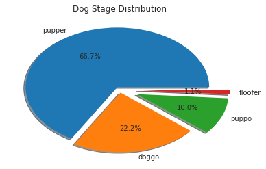

```python
x=df_master['dog_stage'].value_counts()
plt.pie(x, labels=['pupper','doggo','puppo','floofer'],
        shadow=True,explode=(.05,.05,.2,.2),autopct='%1.1f%%');
plt.title('Dog Stage Distribution')
plt.show();
```

```
Text(0.5,0,'Dog stage')
```

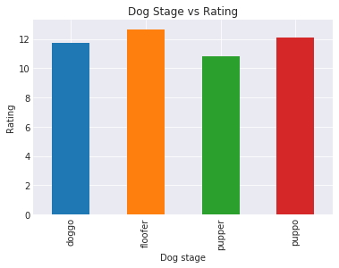

```python
df_master.groupby(['dog_stage'])['rating'].mean().plot(kind='bar');
plt.title('Dog Stage vs Rating')
plt.ylabel('Rating')
plt.xlabel('Dog stage')
```

```
Text(0.5,0,'Dog stage')
```

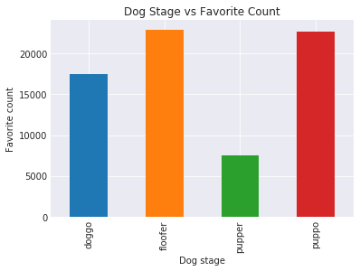

```python
df_master.groupby(['dog_stage'])['favorite_count'].mean().plot(kind='bar');
plt.title('Dog Stage vs Favorite Count')
plt.ylabel('Favorite count')
plt.xlabel('Dog stage')
```

```
Text(0.5,0,'Dog stage')
```

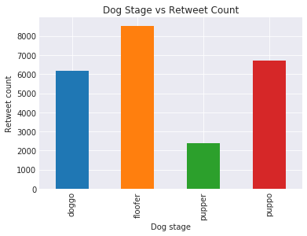

```python
df_master.groupby(['dog_stage'])['retweet_count'].mean().plot(kind='bar');
plt.title('Dog Stage vs Retweet Count')
plt.ylabel('Retweet count')
plt.xlabel('Dog stage')
```

##### Rating distribution

```
Text(0.5,0,'Rating')
```

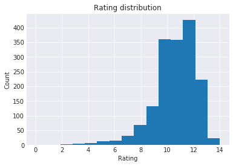

```python
df_master.rating.hist(bins=15);
plt.title('Rating distribution')
plt.ylabel('Count')
plt.xlabel('Rating')
```

##### Relationship between favorite count and retweet count

```
Text(0.5,6.8,'Favorite Count')
```

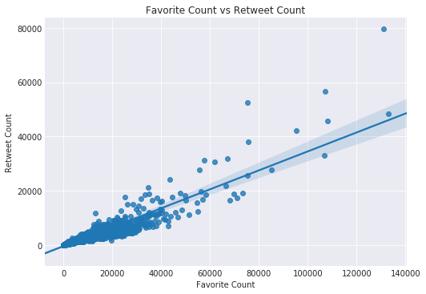

```python
sns.lmplot(data=df_master, x='favorite_count', y='retweet_count', aspect=1.5);
plt.title('Favorite Count vs Retweet Count')
plt.ylabel('Retweet Count')
plt.xlabel('Favorite Count')
```

##### Ratings Effect on Retweet and Favorite Counts

```
Text(0.5,1,'Ratings vs Retweet Counts')
```

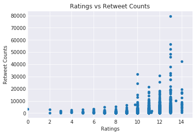

```python
df_master.plot(x='rating', y='retweet_count', kind='scatter');
plt.xlim(0,15)
plt.ylabel('Retweet Counts')
plt.xlabel('Ratings')
plt.title('Ratings vs Retweet Counts')
```

```
Text(0.5,1,'Ratings vs Favorite Counts')
```

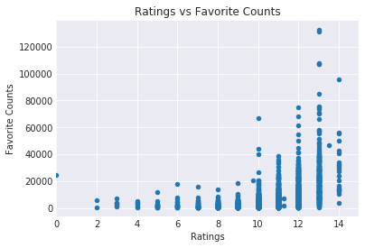

```python
df_master.plot(x='rating', y='favorite_count', kind='scatter');
plt.xlim(0,15)
plt.ylabel('Favorite Counts')
plt.xlabel('Ratings')
plt.title('Ratings vs Favorite Counts')
```

##### Time Effect on Dog Rating

```
Text(0.5,1,'Ratings vs Time')
```

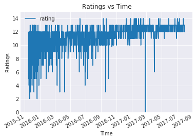

```python
df_master.plot(x='timestamp', y='rating', kind='line');
plt.ylim(0,15)
plt.xlabel('Time')
plt.ylabel('Ratings')
plt.title('Ratings vs Time')
```

```
Text(0.5,1,'Correlation across the Master dataset')
```

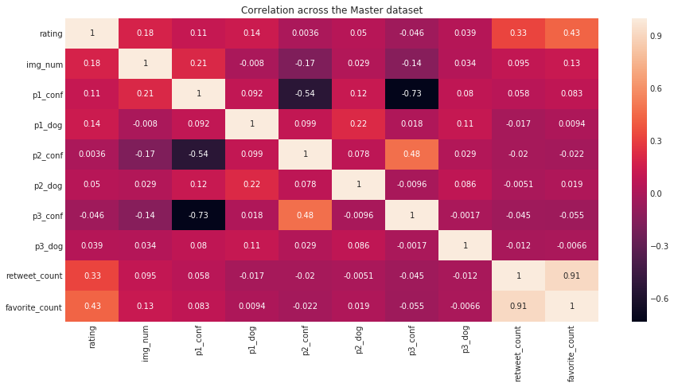

```python
f,ax = plt.subplots(figsize=(15,7))
sns.heatmap(df_master.corr(), annot=True, ax=ax);
plt.title('Correlation across the Master dataset')
```

## Conclusions

WeRateDogs tweet archive was wrangled and analyzed and below are some of the conclusions:

- Noticable top breeds being tweeted are, Golden retriver and Labrador Retriever.
- Most common stage of dog is pupper
- Most dogs were rated 10, 11 and 12
- Retweets and Favorites are highly correlated

## Reference

- [Numpy](https://numpy.org/doc/stable/contents.html)
- [Pandas](https://pandas.pydata.org/docs/reference/index.html#api)
- [Regex](https://www.programiz.com/python-programming/regex)
- [Pie Charts](https://medium.com/@kvnamipara/a-better-visualisation-of-pie-charts-by-matplotlib-935b7667d77f)
- [Capitalize](https://stackoverflow.com/questions/1549641/how-can-i-capitalize-the-first-letter-of-each-word-in-a-string)
- [lmplot](https://seaborn.pydata.org/generated/seaborn.lmplot.html)
- [Python documentation](https://www.w3schools.com/python/default.asp)